# Turkey Migration Map

R_boys

23 December 2018

# Datasets Used & Objectives

### Datasets

- Data set we obtained from the TUIK website contains 4 years of population movement within Turkey.
- Original excel file consists of 329 rows and 86 columns of data.
- Each row represents the destination cities which people migrated to and on each column we can obtain the distribution of migrated population by the place of birth.
- There are 81 distinct Turkish cities as a destination and 83 distinct columns as a place of birth with the addition for people who were born abroad or unknown locations.

### Objectives

- Primary goal of this analysis is to find & address the specific patterns that shape the migration dynamics in Turkey.
- First we will analyze the data how the migration figures evolved in four years and then visualize the common patterns observed along this period.
- Finally we will try to link additional demographic statistics from TUIK and show that what would be the population density across cities if people could migrate to place where they were born instead of where they migrated actually.

# Structure of Data

Cleaned and reshaped versions of dataset we used for our project can be seen below:

### Migration Between Birth Places and Province of Living for 2014 - 2017 (TUIK)

```r
str(clean_data)
```

```
## 'data.frame':    26892 obs. of  4 variables:
##  $ Year       : Date, format: "2014-01-01" "2014-01-01" ...
##  $ Destination: chr  "Adana" "Adana" "Adana" "Adana" ...
##  $ Birth_Place: chr  "Adana" "Adiyaman" "Afyonkarahisar" "Agri" ...
##  $ People     : int  20638 1009 84 184 63 868 325 39 106 80 ...
```

### Breakdown of Population by Birth Places for each Turkish City as of 2016 (TUIK)

```r
str(pop_data)
```

```
## 'data.frame':    6723 obs. of  3 variables:
##  $ Province   : chr  "Adana" "Adiyaman" "Afyonkarahisar" "Agri" ...
##  $ Birth_Place: chr  "Adana" "Adana" "Adana" "Adana" ...
##  $ People     : num  1568874 4023 1579 1163 2319 ...
```

# Impact of Migration on Current Population (1/2)

- Migration by definition might have impact on current population both increasing and decreasing
- In current scope of our analysis, all cities have both status as people migrated to and people migrated from.
- Below graph represent net migration impact over 3 largest cities of Turkey between 2014- 2017

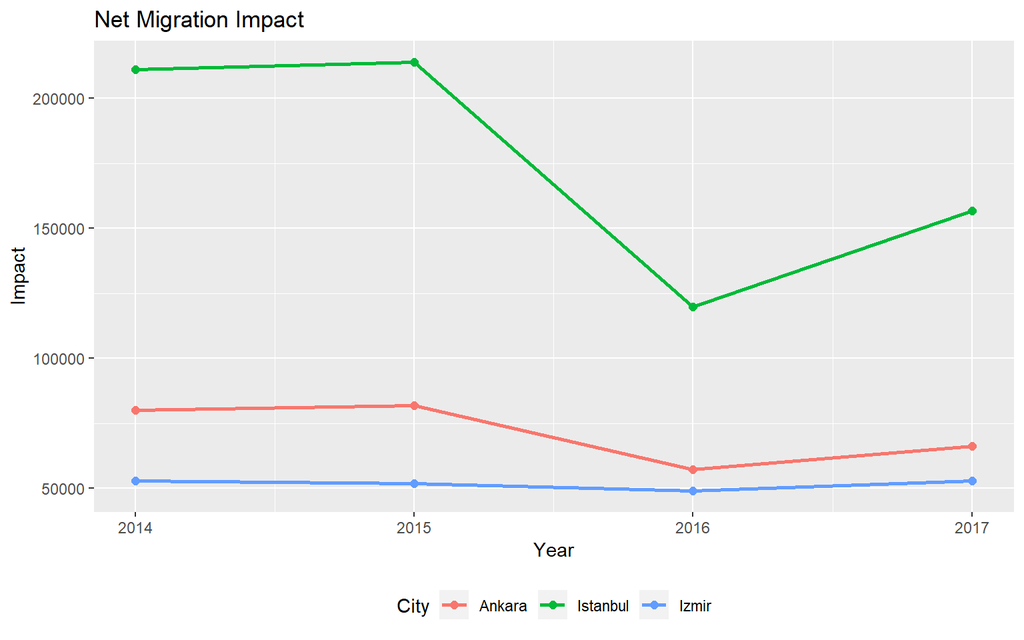

# Impact of Migration on Current Population (2/2)

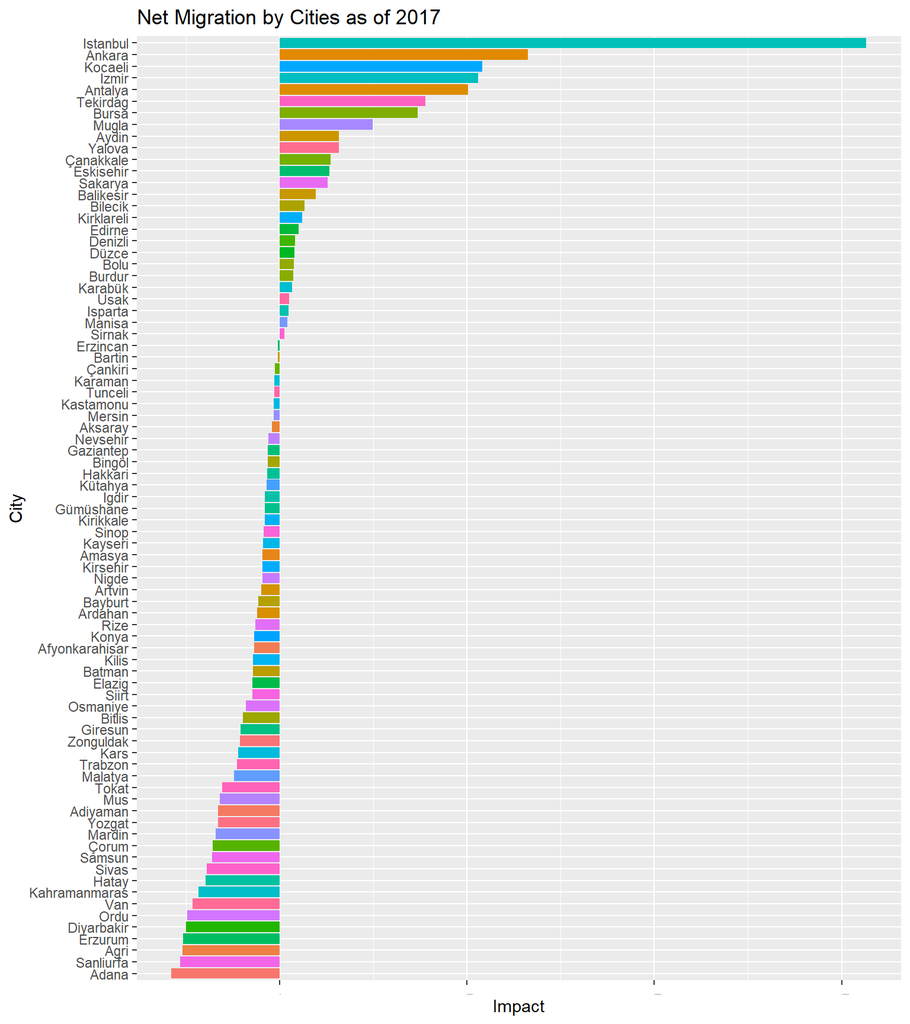

# Geographical Distribution of Migration to Istanbul and Ankara (1/2)

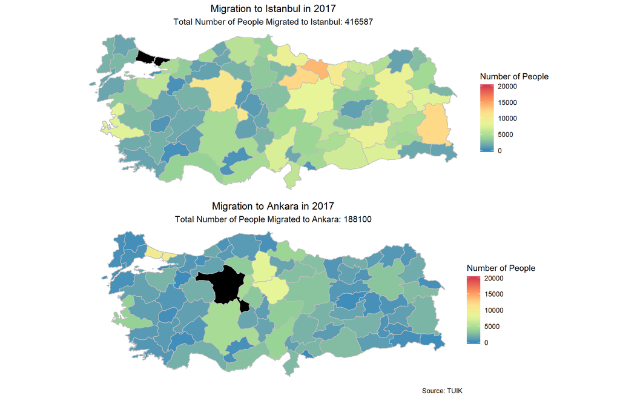

# Geographical Distribution of Migration to Istanbul and Ankara (2/2)

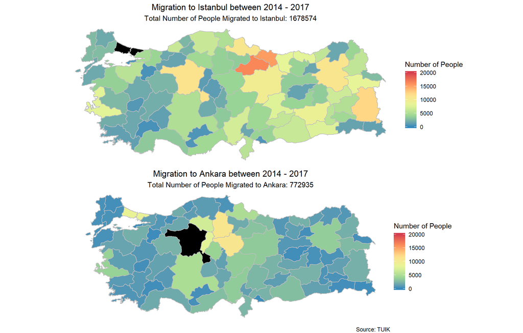

# Regional Relations of Migration

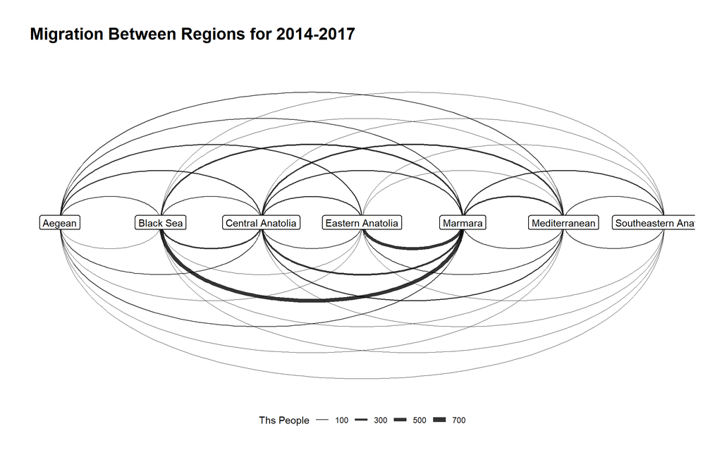